# Multi-Class Model for Tabular Playground Series February 2022 Using Python and Scikit-Learn

### March 21, 2022

Template Credit: Adapted from a template made available by Dr. Jason Brownlee of Machine Learning Mastery. [https://machinelearningmastery.com/]

SUMMARY: The project aims to construct a predictive model using various machine learning algorithms and document the end-to-end steps using a template. The Tabular Playground Series February 2022 dataset is a multi-class modeling situation where we attempt to predict one of several (more than two) possible outcomes.

INTRODUCTION: Kaggle wants to provide an approachable environment for relatively new people in their data science journey. Since January 2021, they have hosted playground-style competitions on Kaggle with fun but less complex, tabular datasets. For this dataset, we want to predict bacteria species based on repeated lossy measurements of DNA snippets. Each row of data contains a spectrum of histograms generated by repeated measurements of a sample, and each row contains the output of all 286 histogram possibilities.

ANALYSIS: The average performance of the machine learning algorithms achieved an accuracy benchmark of 94.19% using the training dataset. Furthermore, we selected Extra Trees as the final model as it processed the training dataset with a final accuracy score of 99.52%. When we processed the test dataset with the final model, the model achieved an accuracy score of 97.26%.

CONCLUSION: In this iteration, the Extra Trees model appeared to be a suitable algorithm for modeling this dataset.

Dataset Used: Tabular Playground Series February 2022

Dataset ML Model: Multi-Class classification with numerical features

Dataset Reference: https://www.kaggle.com/c/tabular-playground-series-feb-2022/data

One source of potential performance benchmarks: https://www.kaggle.com/c/tabular-playground-series-feb-2022/leaderboard

## Task 1 - Prepare Environment

```python
# Retrieve the CPU information
ncpu = !nproc
print("The number of available CPUs is:", ncpu[0])
```

```
The number of available CPUs is: 8
```

### 1.a) Load libraries and modules

```python
# Set the random seed number for reproducible results
RNG_SEED = 888
```

```python
import numpy as np
import pandas as pd
import seaborn as sns
import matplotlib.pyplot as plt
import os
import sys
import math
# import boto3
import zipfile
from datetime import datetime
from sklearn import preprocessing
from sklearn.model_selection import train_test_split
from sklearn.model_selection import StratifiedKFold
from sklearn.model_selection import cross_val_score
from sklearn.model_selection import GridSearchCV
from sklearn.metrics import classification_report
from sklearn.metrics import confusion_matrix
from sklearn.metrics import accuracy_score
from sklearn.pipeline import Pipeline
from sklearn import compose
from sklearn import impute

# from sklearn.feature_selection import RFE
# from imblearn.pipeline import Pipeline
# from imblearn.over_sampling import SMOTE
# from imblearn.under_sampling import RandomUnderSampler

from sklearn.discriminant_analysis import LinearDiscriminantAnalysis
from sklearn.tree import DecisionTreeClassifier
from sklearn.neighbors import KNeighborsClassifier
from sklearn.ensemble import BaggingClassifier
from sklearn.ensemble import RandomForestClassifier
from sklearn.ensemble import ExtraTreesClassifier
```

### 1.b) Set up the controlling parameters and functions

```python
# Begin the timer for the script processing
START_TIME_SCRIPT = datetime.now()

# Set up the number of CPU cores available for multi-thread processing
N_JOBS = 2

# Set up the flag to stop sending progress emails (setting to True will send status emails!)
NOTIFY_STATUS = False

# Set the percentage sizes for splitting the dataset
TEST_SET_RATIO = 0.2
VAL_SET_RATIO = 0.2

# Set the number of folds for cross validation
N_FOLDS = 5

# Set default modeling scoring metric
SCORING_METRIC = 'accuracy'

# Define the directory locations and file names
IMPORT_DATASET = 'tabular-playground-series-feb-2022.zip'
TRAIN_DATASET = 'train.csv'
TEST_DATASET = 'test.csv'
SAMPLE_SUBMISSION = 'sample_submission.csv'
FINAL_SUBMISSION = 'submission_'
```

```python
# Set up the email notification function
def status_notify(msg_text):
    access_key = os.environ.get('SNS_ACCESS_KEY')
    secret_key = os.environ.get('SNS_SECRET_KEY')
    aws_region = os.environ.get('SNS_AWS_REGION')
    topic_arn = os.environ.get('SNS_TOPIC_ARN')
    if (access_key is None) or (secret_key is None) or (aws_region is None):
        sys.exit("Incomplete notification setup info. Script Processing Aborted!!!")
    sns = boto3.client('sns', aws_access_key_id=access_key, aws_secret_access_key=secret_key, region_name=aws_region)
    response = sns.publish(TopicArn=topic_arn, Message=msg_text)
    if response['ResponseMetadata']['HTTPStatusCode'] != 200 :
        print('Status notification not OK with HTTP status code:', response['ResponseMetadata']['HTTPStatusCode'])
```

```python
if NOTIFY_STATUS: status_notify("Task 1 - Prepare Environment has begun! " + datetime.now().strftime('%a %B %d, %Y %I:%M:%S %p'))
```

### 1.c) Load dataset

```python
# Clean up the old files and download directories before receiving new ones
# !rm Rice_Image_Dataset.zip
!rm sample_submission.csv
!rm train.csv
!rm test.csv
```

```python
if not os.path.exists(IMPORT_DATASET):
    !wget https://dainesanalytics.com/datasets/kaggle-tabular-playground-2022feb/tabular-playground-series-feb-2022.zip
```

```python
zip_ref = zipfile.ZipFile(IMPORT_DATASET, 'r')
zip_ref.extractall()
zip_ref.close()
```

```python
df_dataset_import = pd.read_csv(TRAIN_DATASET, index_col=False)

# Take a peek at the dataframe after import
print(df_dataset_import.head())
```

```
   row_id     A0T0G0C10  A0T0G1C9  A0T0G2C8  A0T0G3C7  A0T0G4C6  A0T0G5C5  \
0       0 -9.536743e-07 -0.000010 -0.000043 -0.000114 -0.000200 -0.000240
1       1 -9.536743e-07 -0.000010 -0.000043  0.000886 -0.000200  0.000760
2       2 -9.536743e-07 -0.000002  0.000007  0.000129  0.000268  0.000270
3       3  4.632568e-08 -0.000006  0.000012  0.000245  0.000492  0.000522
4       4 -9.536743e-07 -0.000010 -0.000043 -0.000114 -0.000200 -0.000240

   A0T0G6C4  A0T0G7C3  A0T0G8C2  ...  A8T0G1C1  A8T0G2C0  A8T1G0C1  A8T1G1C0  \
0 -0.000200 -0.000114 -0.000043  ... -0.000086 -0.000043 -0.000086 -0.000086
1 -0.000200 -0.000114 -0.000043  ... -0.000086 -0.000043  0.000914  0.000914
2  0.000243  0.000125  0.000001  ...  0.000084  0.000048  0.000081  0.000106
3  0.000396  0.000197 -0.000003  ...  0.000151  0.000100  0.000180  0.000202
4 -0.000200 -0.000114 -0.000043  ... -0.000086 -0.000043 -0.000086 -0.000086

   A8T2G0C0  A9T0G0C1  A9T0G1C0  A9T1G0C0     A10T0G0C0  \
0 -0.000043 -0.000010 -0.000010 -0.000010 -9.536743e-07
1 -0.000043 -0.000010 -0.000010 -0.000010 -9.536743e-07
2  0.000072  0.000010  0.000008  0.000019  1.046326e-06
3  0.000153  0.000021  0.000015  0.000046 -9.536743e-07
4 -0.000043 -0.000010 -0.000010 -0.000010 -9.536743e-07

                   target
0  Streptococcus_pyogenes
1     Salmonella_enterica
2     Salmonella_enterica
3     Salmonella_enterica
4      Enterococcus_hirae

[5 rows x 288 columns]
```

```python
df_dataset_import.info(verbose=True)
```

```
<class 'pandas.core.frame.DataFrame'>
RangeIndex: 200000 entries, 0 to 199999
Data columns (total 288 columns):
 #    Column     Dtype
---   ------     -----
 0    row_id     int64
 1    A0T0G0C10  float64
 2    A0T0G1C9   float64
 3    A0T0G2C8   float64
 4    A0T0G3C7   float64
 5    A0T0G4C6   float64
 6    A0T0G5C5   float64
 7    A0T0G6C4   float64
 8    A0T0G7C3   float64
 9    A0T0G8C2   float64
```

[output cut: 280 more lines]

```python
print(df_dataset_import.describe())
```

```
              row_id     A0T0G0C10       A0T0G1C9       A0T0G2C8  \
count  200000.000000  2.000000e+05  200000.000000  200000.000000
mean    99999.500000  6.421457e-07      -0.000003      -0.000014
std     57735.171256  8.654927e-05       0.000132       0.000287
min         0.000000 -9.536743e-07      -0.000010      -0.000043
25%     49999.750000 -9.536743e-07      -0.000010      -0.000043
50%     99999.500000 -9.536743e-07      -0.000010      -0.000043
75%    149999.250000 -9.536743e-07      -0.000003      -0.000013
max    199999.000000  9.999046e-03       0.009990       0.009957

            A0T0G3C7       A0T0G4C6       A0T0G5C5       A0T0G6C4  \
count  200000.000000  200000.000000  200000.000000  200000.000000
mean       -0.000010       0.000005       0.000025       0.000014
std         0.000436       0.000683       0.000869       0.000775
min        -0.000114      -0.000200      -0.000240      -0.000200
25%        -0.000114      -0.000200      -0.000240      -0.000200
50%        -0.000114      -0.000200      -0.000237      -0.000199
75%        -0.000004      -0.000011       0.000003      -0.000030
max         0.009886       0.019800       0.019760       0.019800

            A0T0G7C3       A0T0G8C2  ...       A8T0G0C2       A8T0G1C1  \
count  200000.000000  200000.000000  ...  200000.000000  200000.000000
mean       -0.000009      -0.000028  ...       0.000135       0.000348
std         0.000441       0.000107  ...       0.000711       0.001117
min        -0.000114      -0.000043  ...      -0.000043      -0.000086
25%        -0.000114      -0.000043  ...      -0.000043      -0.000086
50%        -0.000114      -0.000043  ...       0.000014       0.000064
75%         0.000004      -0.000028  ...       0.000111       0.000463
max         0.009886       0.009957  ...       0.019957       0.019914

            A8T0G2C0       A8T1G0C1       A8T1G1C0       A8T2G0C0  \
count  200000.000000  200000.000000  200000.000000  200000.000000
mean        0.000253       0.000464       0.000581       0.000379
std         0.000914       0.001238       0.001528       0.001182
min        -0.000043      -0.000086      -0.000086      -0.000043
25%        -0.000043      -0.000086      -0.000086      -0.000043
50%         0.000047       0.000124       0.000114       0.000043
75%         0.000297       0.000684       0.000774       0.000365
max         0.019957       0.019914       0.019914       0.019957

            A9T0G0C1      A9T0G1C0      A9T1G0C0     A10T0G0C0
count  200000.000000  2.000000e+05  2.000000e+05  2.000000e+05
mean        0.000062  8.982134e-05  1.170014e-04  2.215407e-07
std         0.000466  5.475606e-04  6.788277e-04  2.050081e-05
min        -0.000010 -9.536743e-06 -9.536743e-06 -9.536743e-07
25%        -0.000010 -9.536743e-06 -9.536743e-06 -9.536743e-07
50%        -0.000010  4.632568e-07  4.632568e-07 -9.536743e-07
75%         0.000030  6.046326e-05  6.946326e-05 -9.536743e-07
max         0.009990  9.990463e-03  1.999046e-02  9.990463e-04

[8 rows x 287 columns]
```

```python
print(df_dataset_import.isnull().sum())
print('Total number of NaN in the dataframe: ', df_dataset_import.isnull().sum().sum())
```

```
row_id       0
A0T0G0C10    0
A0T0G1C9     0
A0T0G2C8     0
A0T0G3C7     0
            ..
A9T0G0C1     0
A9T0G1C0     0
A9T1G0C0     0
A10T0G0C0    0
target       0
Length: 288, dtype: int64
Total number of NaN in the dataframe:  0
```

```python
# Get grouping size for the target variable
print(df_dataset_import.groupby('target').size())
```

```
target
Bacteroides_fragilis        20139
Campylobacter_jejuni        20063
Enterococcus_hirae          19947
Escherichia_coli            19958
Escherichia_fergusonii      19937
Klebsiella_pneumoniae       19847
Salmonella_enterica         20030
Staphylococcus_aureus       19929
Streptococcus_pneumoniae    20074
Streptococcus_pyogenes      20076
dtype: int64
```

### 1.d) Data Cleaning

```python
# Dropping features with all unique values or no variations
df_dataset_import.drop(columns=['row_id'], inplace=True)

# Take a peek at the dataframe after cleaning
print(df_dataset_import.head())
```

```
      A0T0G0C10  A0T0G1C9  A0T0G2C8  A0T0G3C7  A0T0G4C6  A0T0G5C5  A0T0G6C4  \
0 -9.536743e-07 -0.000010 -0.000043 -0.000114 -0.000200 -0.000240 -0.000200
1 -9.536743e-07 -0.000010 -0.000043  0.000886 -0.000200  0.000760 -0.000200
2 -9.536743e-07 -0.000002  0.000007  0.000129  0.000268  0.000270  0.000243
3  4.632568e-08 -0.000006  0.000012  0.000245  0.000492  0.000522  0.000396
4 -9.536743e-07 -0.000010 -0.000043 -0.000114 -0.000200 -0.000240 -0.000200

   A0T0G7C3  A0T0G8C2  A0T0G9C1  ...  A8T0G1C1  A8T0G2C0  A8T1G0C1  A8T1G1C0  \
0 -0.000114 -0.000043 -0.000010  ... -0.000086 -0.000043 -0.000086 -0.000086
1 -0.000114 -0.000043 -0.000010  ... -0.000086 -0.000043  0.000914  0.000914
2  0.000125  0.000001 -0.000007  ...  0.000084  0.000048  0.000081  0.000106
3  0.000197 -0.000003 -0.000007  ...  0.000151  0.000100  0.000180  0.000202
4 -0.000114 -0.000043 -0.000010  ... -0.000086 -0.000043 -0.000086 -0.000086

   A8T2G0C0  A9T0G0C1  A9T0G1C0  A9T1G0C0     A10T0G0C0  \
0 -0.000043 -0.000010 -0.000010 -0.000010 -9.536743e-07
1 -0.000043 -0.000010 -0.000010 -0.000010 -9.536743e-07
2  0.000072  0.000010  0.000008  0.000019  1.046326e-06
3  0.000153  0.000021  0.000015  0.000046 -9.536743e-07
4 -0.000043 -0.000010 -0.000010 -0.000010 -9.536743e-07

                   target
0  Streptococcus_pyogenes
1     Salmonella_enterica
2     Salmonella_enterica
3     Salmonella_enterica
4      Enterococcus_hirae

[5 rows x 287 columns]
```

```python
df_dataset_import.info(verbose=True)
```

```
<class 'pandas.core.frame.DataFrame'>
RangeIndex: 200000 entries, 0 to 199999
Data columns (total 287 columns):
 #    Column     Dtype
---   ------     -----
 0    A0T0G0C10  float64
 1    A0T0G1C9   float64
 2    A0T0G2C8   float64
 3    A0T0G3C7   float64
 4    A0T0G4C6   float64
 5    A0T0G5C5   float64
 6    A0T0G6C4   float64
 7    A0T0G7C3   float64
 8    A0T0G8C2   float64
 9    A0T0G9C1   float64
```

[output cut: 279 more lines]

```python
print(df_dataset_import.describe())
```

```
          A0T0G0C10       A0T0G1C9       A0T0G2C8       A0T0G3C7  \
count  2.000000e+05  200000.000000  200000.000000  200000.000000
mean   6.421457e-07      -0.000003      -0.000014      -0.000010
std    8.654927e-05       0.000132       0.000287       0.000436
min   -9.536743e-07      -0.000010      -0.000043      -0.000114
25%   -9.536743e-07      -0.000010      -0.000043      -0.000114
50%   -9.536743e-07      -0.000010      -0.000043      -0.000114
75%   -9.536743e-07      -0.000003      -0.000013      -0.000004
max    9.999046e-03       0.009990       0.009957       0.009886

            A0T0G4C6       A0T0G5C5       A0T0G6C4       A0T0G7C3  \
count  200000.000000  200000.000000  200000.000000  200000.000000
mean        0.000005       0.000025       0.000014      -0.000009
std         0.000683       0.000869       0.000775       0.000441
min        -0.000200      -0.000240      -0.000200      -0.000114
25%        -0.000200      -0.000240      -0.000200      -0.000114
50%        -0.000200      -0.000237      -0.000199      -0.000114
75%        -0.000011       0.000003      -0.000030       0.000004
max         0.019800       0.019760       0.019800       0.009886

            A0T0G8C2       A0T0G9C1  ...       A8T0G0C2       A8T0G1C1  \
count  200000.000000  200000.000000  ...  200000.000000  200000.000000
mean       -0.000028      -0.000008  ...       0.000135       0.000348
std         0.000107       0.000083  ...       0.000711       0.001117
min        -0.000043      -0.000010  ...      -0.000043      -0.000086
25%        -0.000043      -0.000010  ...      -0.000043      -0.000086
50%        -0.000043      -0.000010  ...       0.000014       0.000064
75%        -0.000028      -0.000010  ...       0.000111       0.000463
max         0.009957       0.009990  ...       0.019957       0.019914

            A8T0G2C0       A8T1G0C1       A8T1G1C0       A8T2G0C0  \
count  200000.000000  200000.000000  200000.000000  200000.000000
mean        0.000253       0.000464       0.000581       0.000379
std         0.000914       0.001238       0.001528       0.001182
min        -0.000043      -0.000086      -0.000086      -0.000043
25%        -0.000043      -0.000086      -0.000086      -0.000043
50%         0.000047       0.000124       0.000114       0.000043
75%         0.000297       0.000684       0.000774       0.000365
max         0.019957       0.019914       0.019914       0.019957

            A9T0G0C1      A9T0G1C0      A9T1G0C0     A10T0G0C0
count  200000.000000  2.000000e+05  2.000000e+05  2.000000e+05
mean        0.000062  8.982134e-05  1.170014e-04  2.215407e-07
std         0.000466  5.475606e-04  6.788277e-04  2.050081e-05
min        -0.000010 -9.536743e-06 -9.536743e-06 -9.536743e-07
25%        -0.000010 -9.536743e-06 -9.536743e-06 -9.536743e-07
50%        -0.000010  4.632568e-07  4.632568e-07 -9.536743e-07
75%         0.000030  6.046326e-05  6.946326e-05 -9.536743e-07
max         0.009990  9.990463e-03  1.999046e-02  9.990463e-04

[8 rows x 286 columns]
```

```python
print(df_dataset_import.isnull().sum())
print('Total number of NaN in the dataframe: ', df_dataset_import.isnull().sum().sum())
```

```
A0T0G0C10    0
A0T0G1C9     0
A0T0G2C8     0
A0T0G3C7     0
A0T0G4C6     0
            ..
A9T0G0C1     0
A9T0G1C0     0
A9T1G0C0     0
A10T0G0C0    0
target       0
Length: 287, dtype: int64
Total number of NaN in the dataframe:  0
```

```python
# Get grouping size for the target variable
print(df_dataset_import.groupby('target').size())
```

```
target
Bacteroides_fragilis        20139
Campylobacter_jejuni        20063
Enterococcus_hirae          19947
Escherichia_coli            19958
Escherichia_fergusonii      19937
Klebsiella_pneumoniae       19847
Salmonella_enterica         20030
Staphylococcus_aureus       19929
Streptococcus_pneumoniae    20074
Streptococcus_pyogenes      20076
dtype: int64
```

### 1.e) Splitting Data into Sets

```python
# Use variable total_column_count to hold the number of columns in the dataframe
total_column_count = len(df_dataset_import.columns)

# Set up variable total_feature_count for the total number of attribute columns
total_feature_count = total_column_count-1

# We create attribute-only and target-only datasets (df_features_train and df_target_train)
df_target_train = df_dataset_import['target']
df_features_train = df_dataset_import.drop(['target'], axis=1)

print("df_dataset_import.shape: {} df_features_train.shape: {} df_target_train.shape: {}".format(df_dataset_import.shape, df_features_train.shape, df_target_train.shape))
```

```
df_dataset_import.shape: (200000, 287) df_features_train.shape: (200000, 286) df_target_train.shape: (200000,)
```

### 1.f) Set up the parameters for data visualization

```python
# Set up the number of row and columns for visualization display. display_rows * display_columns should be >= total_feature_count
display_columns = 4
if total_feature_count % display_columns == 0 :
    display_rows = total_feature_count // display_columns
else :
    display_rows = (total_feature_count // display_columns) + 1

# Set figure width to display the data visualization plots
fig_size = plt.rcParams["figure.figsize"]
fig_size[0] = display_columns * 4
fig_size[1] = display_rows * 4
plt.rcParams["figure.figsize"] = fig_size
```

```python
if NOTIFY_STATUS: status_notify("Task 1 - Prepare Environment completed! " + datetime.now().strftime('%a %B %d, %Y %I:%M:%S %p'))
```

## Task 2 - Summarize and Visualize Data

```python
if NOTIFY_STATUS: status_notify("Task 2 - Summarize and Visualize Data has begun! " + datetime.now().strftime('%a %B %d, %Y %I:%M:%S %p'))
```

[figure not shown]

```python
# Histograms for each attribute
df_features_train.plot(kind='hist', subplots=True, layout=(display_rows, display_columns))
plt.show()
```

[figure not shown]

```python
# Box and Whisker plot for each attribute
df_features_train.plot(kind='box', subplots=True, layout=(display_rows, display_columns))
plt.show()
```

```python
# # Correlation matrix
# fig = plt.figure(figsize=(20, 20))
# correlations = df_features_train.corr(method='pearson')
# sns.heatmap(correlations, annot=True, cmap=plt.cm.PuBu)
# plt.show()
```

```python
if NOTIFY_STATUS: status_notify("Task 2 - Summarize and Visualize Data completed! " + datetime.now().strftime('%a %B %d, %Y %I:%M:%S %p'))
```

## Task 3 - Pre-process Data

```python
if NOTIFY_STATUS: status_notify("Task 3 - Pre-process Data has begun! " + datetime.now().strftime('%a %B %d, %Y %I:%M:%S %p'))
```

### 3.a) Feature Scaling and Data Pre-Processing

```python
# Compose pipeline for the numerical and categorical features (Block #1 of 2)
numeric_columns = df_features_train.select_dtypes(include=['float64']).columns
numeric_transformer = Pipeline(steps=[
    ('imputer', impute.SimpleImputer(strategy="constant", fill_value=0)),
    ('scaler', preprocessing.MinMaxScaler())
])
categorical_columns = df_features_train.select_dtypes(include=['object','bool','category']).columns
categorical_transformer = Pipeline(steps=[
    ('imputer', impute.SimpleImputer(strategy='constant', fill_value='UKNOWN')),
    ('onehot', preprocessing.OneHotEncoder(sparse=False, handle_unknown='ignore'))
])

print("Number of numerical columns:", len(numeric_columns))
print("Number of categorical columns:", len(categorical_columns))
print("Total number of columns in the feature dataframe:", df_features_train.shape[1])
```

```
Number of numerical columns: 286
Number of categorical columns: 0
Total number of columns in the feature dataframe: 286
```

```python
# Compose pipeline for the numerical and categorical features (Block #2 of 2)
preprocessor = compose.ColumnTransformer(transformers=[
    ('num', numeric_transformer, numeric_columns),
    ('cat', categorical_transformer, categorical_columns)
], remainder='passthrough')
```

### 3.b) Training Data Balancing

```python
# Not applicable for this iteration of the project
```

### 3.c) Feature Selection

```python
# Not applicable for this iteration of the project
```

### 3.d) Display the Final Datasets for Model-Building

```python
# Finalize the training dataset for the modeling activities
array_features_train = preprocessor.fit_transform(df_features_train)
# array_features_train = df_features_train.to_numpy()
label_encoder = preprocessing.LabelEncoder()
array_target_train = label_encoder.fit_transform(df_target_train)
print("array_features_train.shape: {} array_target_train.shape: {}".format(array_features_train.shape, array_target_train.shape))
```

```
array_features_train.shape: (200000, 286) array_target_train.shape: (200000,)
```

```python
if NOTIFY_STATUS: status_notify("Task 3 - Pre-process Data completed! " + datetime.now().strftime('%a %B %d, %Y %I:%M:%S %p'))
```

## Task 4 - Train and Tune Models

```python
if NOTIFY_STATUS: status_notify("Task 4 - Train and Tune Models has begun! " + datetime.now().strftime('%a %B %d, %Y %I:%M:%S %p'))
```

### 4.a) Set test options and evaluation metric

```python
# Set up Algorithms Spot-Checking Array
start_time_training = datetime.now()
train_models = []
train_results = []
train_model_names = []
train_metrics = []
```

```python
train_models.append(('LDA', LinearDiscriminantAnalysis()))
train_models.append(('CART', DecisionTreeClassifier(random_state=RNG_SEED)))
train_models.append(('KNN', KNeighborsClassifier(n_jobs=N_JOBS)))
train_models.append(('BGT', BaggingClassifier(random_state=RNG_SEED, n_jobs=N_JOBS)))
train_models.append(('RNF', RandomForestClassifier(random_state=RNG_SEED, n_jobs=N_JOBS)))
train_models.append(('EXT', ExtraTreesClassifier(random_state=RNG_SEED, n_jobs=N_JOBS)))
```

```python
# Generate model in turn
for name, model in train_models:
	if NOTIFY_STATUS: status_notify("Algorithm", name, "modeling has begun! " + datetime.now().strftime('%a %B %d, %Y %I:%M:%S %p'))
	start_time_module = datetime.now()
	kfold = StratifiedKFold(n_splits=N_FOLDS, shuffle=True, random_state=RNG_SEED)
	cv_results = cross_val_score(model, array_features_train, array_target_train, cv=kfold, scoring=SCORING_METRIC, n_jobs=N_JOBS, verbose=1)
	train_results.append(cv_results)
	train_model_names.append(name)
	train_metrics.append(cv_results.mean())
	print("%s: %f (%f)" % (name, cv_results.mean(), cv_results.std()))
	print(model)
	print ('Model training time:', (datetime.now() - start_time_module), '\n')
	if NOTIFY_STATUS: status_notify("Algorithm", name, "modeling completed! " + datetime.now().strftime('%a %B %d, %Y %I:%M:%S %p'))
print ('Average metrics (' + SCORING_METRIC + ') from all models:', np.mean(train_metrics))
print ('Total training time for all models:', (datetime.now() - start_time_training))
```

```
[Parallel(n_jobs=2)]: Using backend LokyBackend with 2 concurrent workers.
[Parallel(n_jobs=2)]: Done   5 out of   5 | elapsed:   39.4s finished
[Parallel(n_jobs=2)]: Using backend LokyBackend with 2 concurrent workers.
```

```
LDA: 0.744715 (0.000968)
LinearDiscriminantAnalysis()
Model training time: 0:00:39.496619
```

```
[Parallel(n_jobs=2)]: Done   5 out of   5 | elapsed:  1.7min finished
[Parallel(n_jobs=2)]: Using backend LokyBackend with 2 concurrent workers.
```

```
CART: 0.976010 (0.000679)
DecisionTreeClassifier(random_state=888)
Model training time: 0:01:43.635005
```

```
[Parallel(n_jobs=2)]: Done   5 out of   5 | elapsed: 15.1min finished
[Parallel(n_jobs=2)]: Using backend LokyBackend with 2 concurrent workers.
```

```
KNN: 0.957565 (0.000420)
KNeighborsClassifier(n_jobs=2)
Model training time: 0:15:05.021542
```

```
[Parallel(n_jobs=2)]: Done   5 out of   5 | elapsed:  6.0min finished
[Parallel(n_jobs=2)]: Using backend LokyBackend with 2 concurrent workers.
```

```
BGT: 0.985655 (0.000743)
BaggingClassifier(n_jobs=2, random_state=888)
Model training time: 0:06:01.285482
```

```
[Parallel(n_jobs=2)]: Done   5 out of   5 | elapsed:  3.2min finished
[Parallel(n_jobs=2)]: Using backend LokyBackend with 2 concurrent workers.
```

```
RNF: 0.993775 (0.000842)
RandomForestClassifier(n_jobs=2, random_state=888)
Model training time: 0:03:09.751144

EXT: 0.993910 (0.000442)
ExtraTreesClassifier(n_jobs=2, random_state=888)
Model training time: 0:01:54.605752

Average metrics (accuracy) from all models: 0.9419383333333333
Total training time for all models: 0:28:33.812218
```

```
[Parallel(n_jobs=2)]: Done   5 out of   5 | elapsed:  1.9min finished
```

### 4.b) Spot-checking baseline algorithms

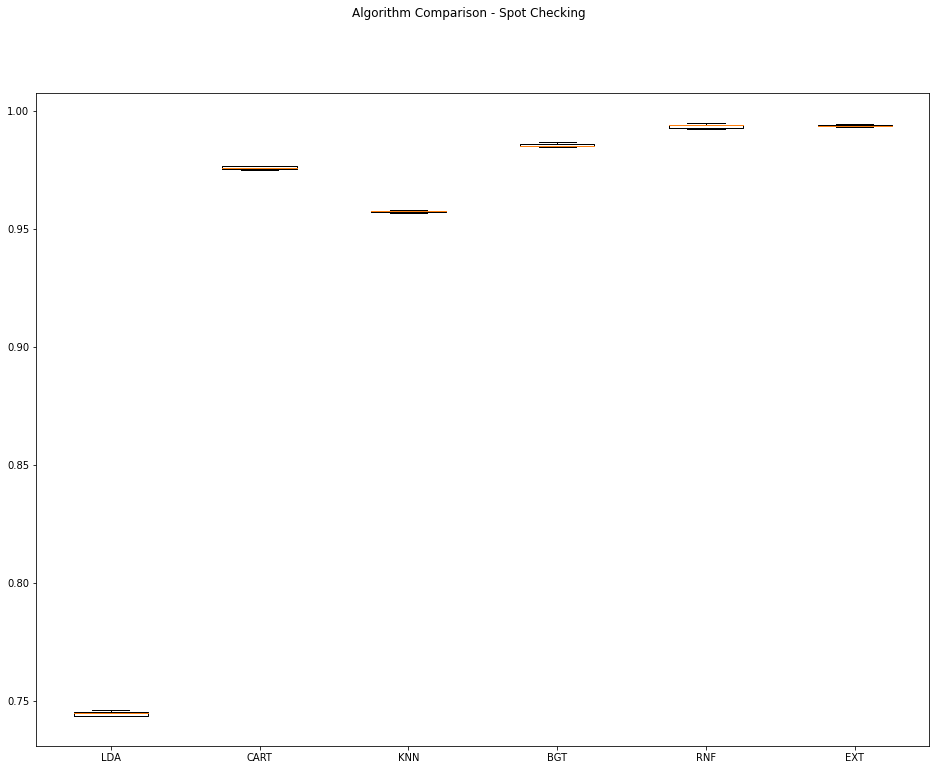

```python
fig = plt.figure(figsize=(16,12))
fig.suptitle('Algorithm Comparison - Spot Checking')
ax = fig.add_subplot(111)
plt.boxplot(train_results)
ax.set_xticklabels(train_model_names)
plt.show()
```

```python
if NOTIFY_STATUS: status_notify("Task 4 - Train and Tune Models completed! " + datetime.now().strftime('%a %B %d, %Y %I:%M:%S %p'))
```

### 4.c) Algorithm Tuning

```python
# Set up the comparison array
tune_results = []
tune_model_names = []
```

```python
# Tuning algorithm #1
start_time_module = datetime.now()
if NOTIFY_STATUS: status_notify("Algorithm #1 tuning has begun! " + datetime.now().strftime('%a %B %d, %Y %I:%M:%S %p'))

tune_model1 = BaggingClassifier(random_state=RNG_SEED, n_jobs=N_JOBS)
tune_model_names.append('BGT')
paramGrid1 = dict(n_estimators=np.array([10, 20, 30, 50]))

kfold = StratifiedKFold(n_splits=N_FOLDS, shuffle=True, random_state=RNG_SEED)
grid1 = GridSearchCV(estimator=tune_model1, param_grid=paramGrid1, scoring=SCORING_METRIC, cv=kfold, n_jobs=N_JOBS, verbose=1)
grid_result1 = grid1.fit(array_features_train, array_target_train)

print("Best: %f using %s" % (grid_result1.best_score_, grid_result1.best_params_))
tune_results.append(grid_result1.cv_results_['mean_test_score'])
means = grid_result1.cv_results_['mean_test_score']
stds = grid_result1.cv_results_['std_test_score']
params = grid_result1.cv_results_['params']
for mean, stdev, param in zip(means, stds, params):
    print("%f (%f) with: %r" % (mean, stdev, param))
print ('Model training time:', (datetime.now() - start_time_module))
if NOTIFY_STATUS: status_notify("Algorithm #1 tuning completed! " + datetime.now().strftime('%a %B %d, %Y %I:%M:%S %p'))
```

```
Fitting 5 folds for each of 4 candidates, totalling 20 fits
Best: 0.989160 using {'n_estimators': 50}
0.985655 (0.000743) with: {'n_estimators': 10}
0.987800 (0.000501) with: {'n_estimators': 20}
0.988745 (0.000509) with: {'n_estimators': 30}
0.989160 (0.000400) with: {'n_estimators': 50}
Model training time: 1:18:08.206384
```

```python
best_paramKey1 = list(grid_result1.best_params_.keys())[0]
best_paramValue1 = list(grid_result1.best_params_.values())[0]
print("Captured the best parameter for algorithm #1:", best_paramKey1, '=', best_paramValue1)
```

```
Captured the best parameter for algorithm #1: n_estimators = 50
```

```python
# Tuning algorithm #2
start_time_module = datetime.now()
if NOTIFY_STATUS: status_notify("Algorithm #2 tuning has begun! " + datetime.now().strftime('%a %B %d, %Y %I:%M:%S %p'))

tune_model2 = ExtraTreesClassifier(random_state=RNG_SEED, n_jobs=N_JOBS)
tune_model_names.append('EXT')
paramGrid2 = dict(n_estimators=np.array([100, 300, 500, 750]))

kfold = StratifiedKFold(n_splits=N_FOLDS, shuffle=True, random_state=RNG_SEED)
grid2 = GridSearchCV(estimator=tune_model2, param_grid=paramGrid2, scoring=SCORING_METRIC, cv=kfold, n_jobs=N_JOBS, verbose=1)
grid_result2 = grid2.fit(array_features_train, array_target_train)

print("Best: %f using %s" % (grid_result2.best_score_, grid_result2.best_params_))
tune_results.append(grid_result2.cv_results_['mean_test_score'])
means = grid_result2.cv_results_['mean_test_score']
stds = grid_result2.cv_results_['std_test_score']
params = grid_result2.cv_results_['params']
for mean, stdev, param in zip(means, stds, params):
    print("%f (%f) with: %r" % (mean, stdev, param))
print ('Model training time:', (datetime.now() - start_time_module))
if NOTIFY_STATUS: status_notify("Algorithm #2 tuning completed! " + datetime.now().strftime('%a %B %d, %Y %I:%M:%S %p'))
```

```
Fitting 5 folds for each of 4 candidates, totalling 20 fits
```

```
Best: 0.995275 using {'n_estimators': 750}
0.993910 (0.000442) with: {'n_estimators': 100}
0.994710 (0.000678) with: {'n_estimators': 300}
0.995015 (0.000548) with: {'n_estimators': 500}
0.995275 (0.000562) with: {'n_estimators': 750}
Model training time: 0:35:56.219291
```

```python
best_paramKey2 = list(grid_result2.best_params_.keys())[0]
best_paramValue2 = list(grid_result2.best_params_.values())[0]
print("Captured the best parameter for algorithm #2:", best_paramKey2, '=', best_paramValue2)
```

```
Captured the best parameter for algorithm #2: n_estimators = 750
```

### 4.d) Compare Algorithms After Tuning

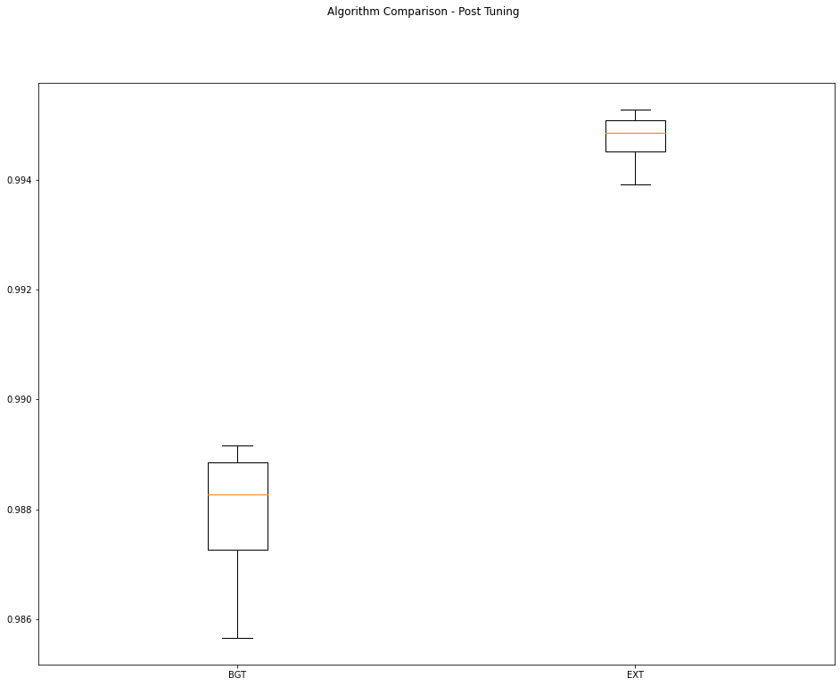

```python
fig = plt.figure(figsize=(16,12))
fig.suptitle('Algorithm Comparison - Post Tuning')
ax = fig.add_subplot(111)
plt.boxplot(tune_results)
ax.set_xticklabels(tune_model_names)
plt.show()
```

```python
if NOTIFY_STATUS: status_notify("Task 4 - Train and Tune Models completed! " + datetime.now().strftime('%a %B %d, %Y %I:%M:%S %p'))
```

## Task 5 - Finalize Model and Make Predictions

```python
if NOTIFY_STATUS: status_notify("Task 5 - Finalize Model and Make Predictions has begun! " + datetime.now().strftime('%a %B %d, %Y %I:%M:%S %p'))
```

### 5.a) Train the Final Model

```python
final_model = ExtraTreesClassifier(n_estimators=best_paramValue2, random_state=RNG_SEED, n_jobs=N_JOBS)
final_model.fit(array_features_train, array_target_train)
print(final_model)
```

```
ExtraTreesClassifier(n_estimators=750, n_jobs=2, random_state=888)
```

### 5.b) Load Test Dataset and Make Predictions

```python
df_features_test = pd.read_csv(TEST_DATASET, index_col=False)

# Take a peek at the dataframe after import
print(df_features_test.head())
```

```
   row_id     A0T0G0C10  A0T0G1C9      A0T0G2C8  A0T0G3C7  A0T0G4C6  A0T0G5C5  \
0  200000 -9.536743e-07 -0.000002 -9.153442e-07  0.000024  0.000034 -0.000002
1  200001 -9.536743e-07 -0.000010 -4.291534e-05 -0.000114  0.001800 -0.000240
2  200002  4.632568e-08  0.000003  8.465576e-08 -0.000014  0.000007 -0.000005
3  200003 -9.536743e-07 -0.000008  8.084656e-06  0.000216  0.000420  0.000514
4  200004 -9.536743e-07 -0.000010 -4.291534e-05 -0.000114 -0.000200 -0.000240

   A0T0G6C4  A0T0G7C3  A0T0G8C2  ...  A8T0G0C2  A8T0G1C1  A8T0G2C0  A8T1G0C1  \
0  0.000021  0.000024 -0.000009  ...  0.000039  0.000085  0.000055  0.000108
1  0.001800 -0.000114  0.000957  ... -0.000043  0.000914 -0.000043 -0.000086
2 -0.000004  0.000003  0.000004  ...  0.000041  0.000102  0.000084  0.000111
3  0.000452  0.000187 -0.000005  ...  0.000069  0.000158  0.000098  0.000175
4 -0.000200 -0.000114 -0.000043  ... -0.000043 -0.000086 -0.000043 -0.000086

   A8T1G1C0  A8T2G0C0  A9T0G0C1  A9T0G1C0  A9T1G0C0     A10T0G0C0
0  0.000090  0.000059  0.000010  0.000006  0.000027  4.632568e-08
1 -0.000086 -0.000043 -0.000010 -0.000010 -0.000010 -9.536743e-07
2  0.000117  0.000070  0.000020  0.000030  0.000021  4.632568e-08
3  0.000217  0.000150  0.000018  0.000016  0.000051 -9.536743e-07
4  0.000914 -0.000043 -0.000010 -0.000010  0.000990 -9.536743e-07

[5 rows x 287 columns]
```

```python
id_column_name = df_features_test.columns[0]
df_kaggle_submission = pd.DataFrame()
df_kaggle_submission[id_column_name] = df_features_test[id_column_name]
print(df_kaggle_submission.head())
```

```
   row_id
0  200000
1  200001
2  200002
3  200003
4  200004
```

```python
# Dropping unnecessary features
df_features_test.drop(columns=[id_column_name], inplace=True)

# Take a peek at the dataframe after cleaning
print(df_features_test.head())
```

```
      A0T0G0C10  A0T0G1C9      A0T0G2C8  A0T0G3C7  A0T0G4C6  A0T0G5C5  \
0 -9.536743e-07 -0.000002 -9.153442e-07  0.000024  0.000034 -0.000002
1 -9.536743e-07 -0.000010 -4.291534e-05 -0.000114  0.001800 -0.000240
2  4.632568e-08  0.000003  8.465576e-08 -0.000014  0.000007 -0.000005
3 -9.536743e-07 -0.000008  8.084656e-06  0.000216  0.000420  0.000514
4 -9.536743e-07 -0.000010 -4.291534e-05 -0.000114 -0.000200 -0.000240

   A0T0G6C4  A0T0G7C3  A0T0G8C2  A0T0G9C1  ...  A8T0G0C2  A8T0G1C1  A8T0G2C0  \
0  0.000021  0.000024 -0.000009 -0.000008  ...  0.000039  0.000085  0.000055
1  0.001800 -0.000114  0.000957 -0.000010  ... -0.000043  0.000914 -0.000043
2 -0.000004  0.000003  0.000004 -0.000008  ...  0.000041  0.000102  0.000084
3  0.000452  0.000187 -0.000005 -0.000008  ...  0.000069  0.000158  0.000098
4 -0.000200 -0.000114 -0.000043 -0.000010  ... -0.000043 -0.000086 -0.000043

   A8T1G0C1  A8T1G1C0  A8T2G0C0  A9T0G0C1  A9T0G1C0  A9T1G0C0     A10T0G0C0
0  0.000108  0.000090  0.000059  0.000010  0.000006  0.000027  4.632568e-08
1 -0.000086 -0.000086 -0.000043 -0.000010 -0.000010 -0.000010 -9.536743e-07
2  0.000111  0.000117  0.000070  0.000020  0.000030  0.000021  4.632568e-08
3  0.000175  0.000217  0.000150  0.000018  0.000016  0.000051 -9.536743e-07
4 -0.000086  0.000914 -0.000043 -0.000010 -0.000010  0.000990 -9.536743e-07

[5 rows x 286 columns]
```

```python
# Finalize the test dataset for the testing activities
array_features_test = preprocessor.transform(df_features_test)
# array_features_test = df_features_test.to_numpy()
print("Transformed features from df_features_test.shape: {} to array_features_test.shape: {}".format(df_features_test.shape, array_features_test.shape))
```

```
Transformed features from df_features_test.shape: (100000, 286) to array_features_test.shape: (100000, 286)
```

```python
# Make batched predictions
# test_predictions =  label_encoder.inverse_transform(np.argmax(final_model.predict(array_features_test), axis=-1))
test_predictions =  label_encoder.inverse_transform(final_model.predict(array_features_test))
print(test_predictions)
```

```
['Escherichia_fergusonii' 'Salmonella_enterica' 'Enterococcus_hirae' ...
 'Bacteroides_fragilis' 'Bacteroides_fragilis' 'Streptococcus_pyogenes']
```

```python
df_sample_submission = pd.read_csv(SAMPLE_SUBMISSION, index_col=False)
df_sample_submission.drop(columns=[id_column_name], inplace=True)
submission_header = list(df_sample_submission.columns)
print(submission_header)
```

```
['target']
```

```python
df_kaggle_submission[submission_header[0]] = test_predictions
print(df_kaggle_submission.head())
```

```
   row_id                  target
0  200000  Escherichia_fergusonii
1  200001     Salmonella_enterica
2  200002      Enterococcus_hirae
3  200003     Salmonella_enterica
4  200004   Staphylococcus_aureus
```

```python
submission_file = df_kaggle_submission.to_csv(header=True, index=False)
filename = FINAL_SUBMISSION + datetime.now().strftime('%Y%m%d-%H%M') + '.csv'
with open(filename, 'w') as f:
    f.write(submission_file)
    print('Completed writing output file: ' + filename)
```

```
Completed writing output file: submission_20220311-1802.csv
```

```python
if NOTIFY_STATUS: status_notify("Task 5 - Finalize Model and Make Predictions completed! " + datetime.now().strftime('%a %B %d, %Y %I:%M:%S %p'))
```

```python
print ('Total time for the script:',(datetime.now() - START_TIME_SCRIPT))
```

```
Total time for the script: 2:32:23.571615
```